# HarvardX PH125.9x Capstone Project: Movielens 10m

David Mc Manus

6/14/2022

# Introduction

## Background

Launched in 2006,and running through 2009, the Netflix Prize open competition sought submissions of recommendation systems that would represent a 10% improvement on their own system, Cinematch. This competition became quite popular with thousands of teams competing for the grand prize of $1,000,000 in 2009. The wining team, BellKor’s Pragmatic Chaos, achieved a final validation RSME of 0.8567(1).

## Data Set

The Movielens 10M dataset, compiled by GroupLens Research, contains 10 million ratings for 10,000 movies, that were submitted to movielens.com. Each row represents an individual rating, and contains the user id, movie id, rating, timestamp, rating, and genre.

## Aim

Although the competition is no longer running, this project aims to create a movie recommendation system that will improve upon the winning test RSME of 0.8567.

## Required Packages

### Memory Allocation

In order to help improve speed and resolve memory related errors, it is advised to change the memory allocation. This can be done with the following code

```
## [1] 56000
```

## Importing Data Set

10% of the dataset has be partitioned, and used only for the final validation test.

# Analysing the Dataset

Before we start to build any models, we should learn more about the data we are working with.

## General Analysis

### Structure of the Dataset

edX Data Set

| userId | movieId | rating | timestamp | title | genres |
| --- | --- | --- | --- | --- | --- |
| 1 | 122 | 5 | 838985046 | Boomerang (1992) | Comedy\|Romance |
| 1 | 185 | 5 | 838983525 | Net, The (1995) | Action\|Crime\|Thriller |
| 1 | 292 | 5 | 838983421 | Outbreak (1995) | Action\|Drama\|Sci-Fi\|Thriller |
| 1 | 316 | 5 | 838983392 | Stargate (1994) | Action\|Adventure\|Sci-Fi |
| 1 | 329 | 5 | 838983392 | Star Trek: Generations (1994) | Action\|Adventure\|Drama\|Sci-Fi |
| 1 | 355 | 5 | 838984474 | Flintstones, The (1994) | Children\|Comedy\|Fantasy |

As we can see, while each row represents a single rating, it also includes the user ID, movie ID, a timestamp, the movie’s title including year of release, and the genre(s).

### Number of Movies and Users

Here we can see how many users and movies make up the set

Number of User and Movies

| n_users | n_movies |
| --- | --- |
| 69878 | 10677 |

## Analysing Rating Patterns

### The Least and Most Rated Movies

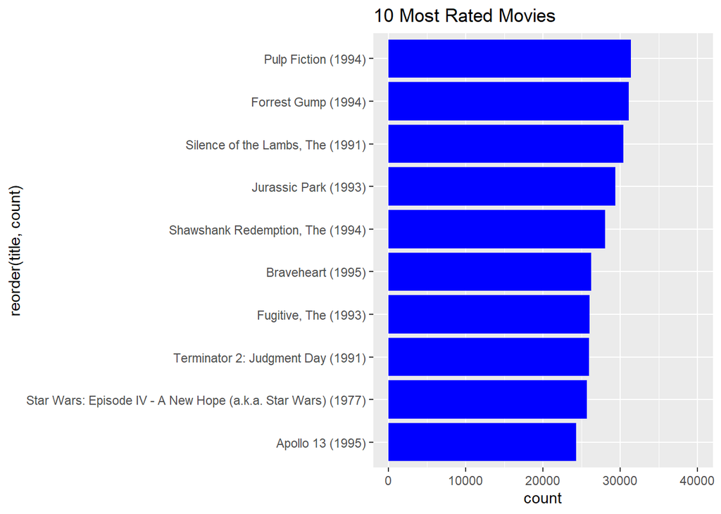

[figure not shown]

As we can clearly see, some movie are rated more often then others.

### Average Number of Ratings for Top 10 Most and Least Rated Movies

Average Number of Ratings for the 10 Most Rated Movies

| Average |
| --- |
| 27834.8 |

Average Number of Ratings for the 10 Least Rated Movies

| Average |
| --- |
| 1 |

In fact, as we can see the difference between the averages of two groups is very stark.

### Number of Ratings for 10 Highest Rated Movies

Top 10 Highest Rated Movies

| title | mean | count |
| --- | --- | --- |
| Blue Light, The (Das Blaue Licht) (1932) | 5.00 | 1 |
| Fighting Elegy (Kenka erejii) (1966) | 5.00 | 1 |
| Hellhounds on My Trail (1999) | 5.00 | 1 |
| Satan’s Tango (Sátántangó) (1994) | 5.00 | 2 |
| Shadows of Forgotten Ancestors (1964) | 5.00 | 1 |
| Sun Alley (Sonnenallee) (1999) | 5.00 | 1 |
| Constantine’s Sword (2007) | 4.75 | 2 |
| Human Condition II, The (Ningen no joken II) (1959) | 4.75 | 4 |
| Human Condition III, The (Ningen no joken III) (1961) | 4.75 | 4 |
| Who’s Singin’ Over There? (a.k.a. Who Sings Over There) (Ko to tamo peva) (1980) | 4.75 | 4 |

The low number of ratings are having a considerable impact on the mean scores, on what appears to be rather obscure movies.

### Ratings by Genre

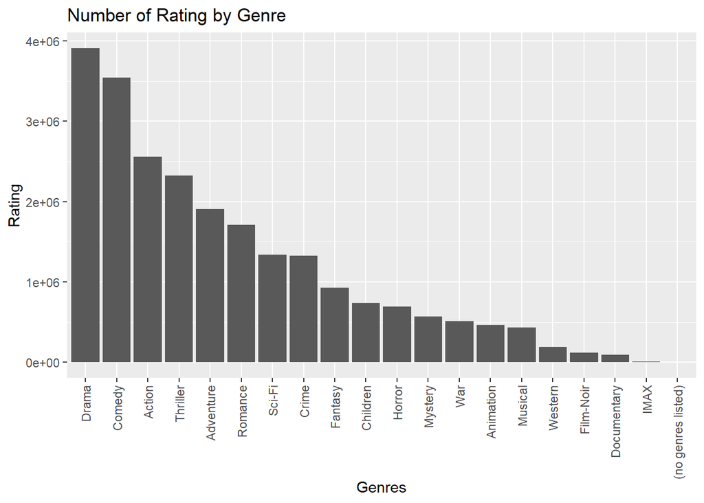

Some genres are also rated more often than others.

### Users by Number of Ratings

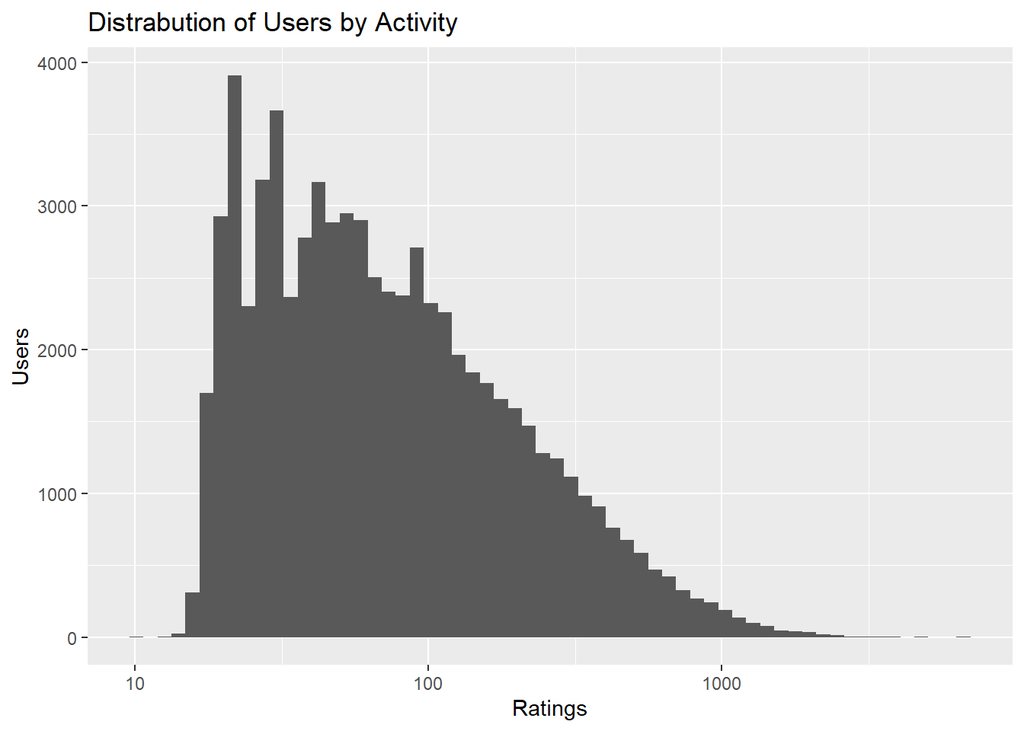

We can see that some users are more active than others.

### Frequency of Ratings

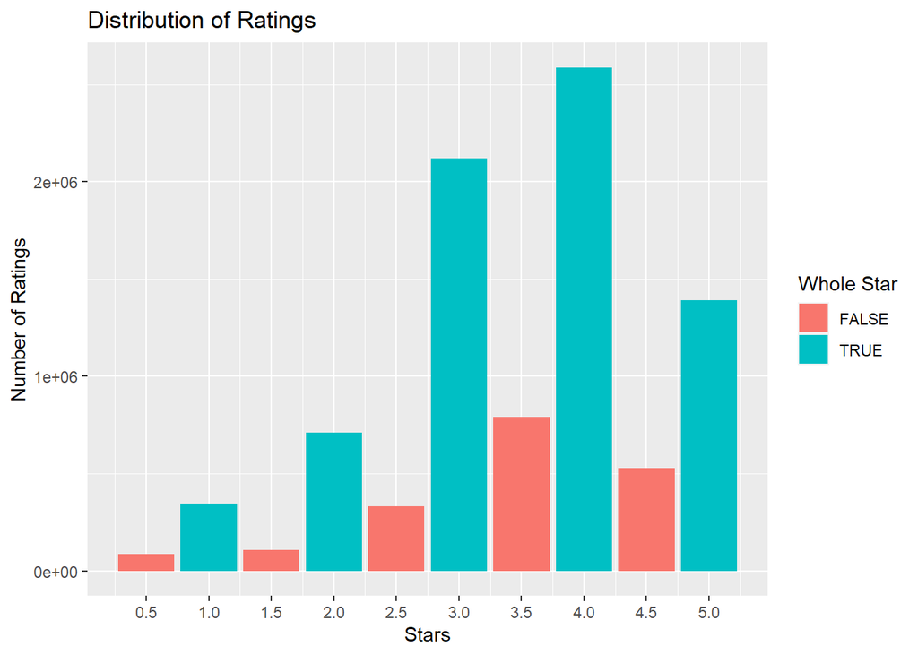

Users are also more likely to give full star ratings, with 4, 3, and 5 being the most popular.

## Analysing the Mean Ratings

### Mean Rating by Genre

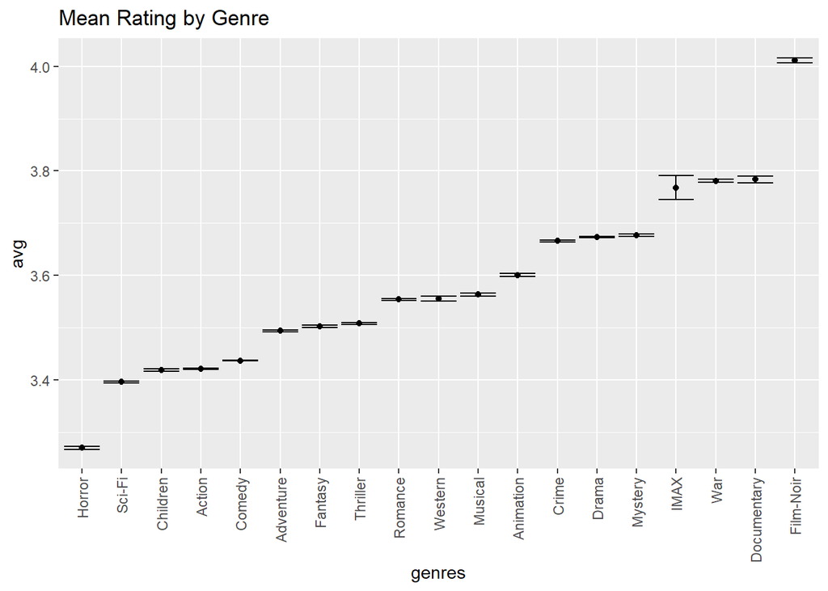

Some genres are rated higher than others, with Film-Noir being rated the highest, followed by Documentary and War movies being second and third, respectively.

### Mean Rating by Release Year

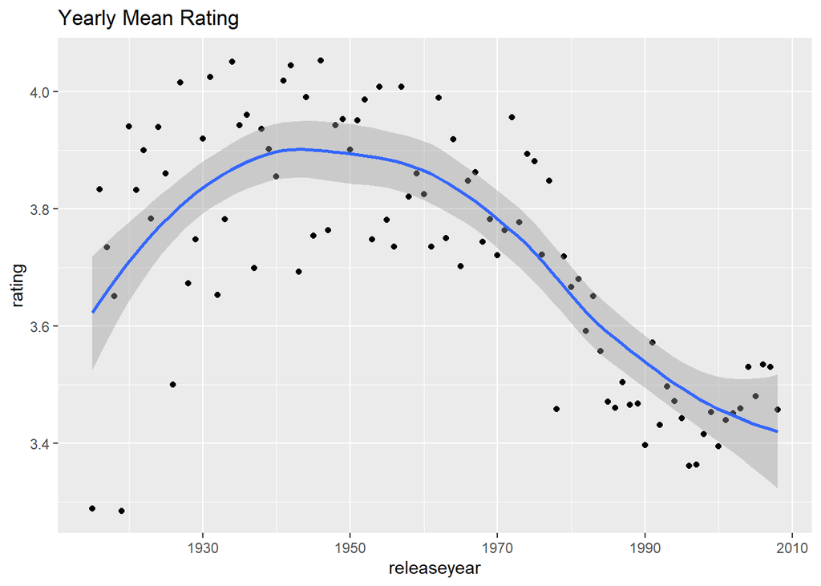

There appears to be a pattern with the mean increasing until the 40’s, starts to fall in the 50’s with the rate of fall increasing around the 60’s.

### Release Year’s Mean Rating by Genre

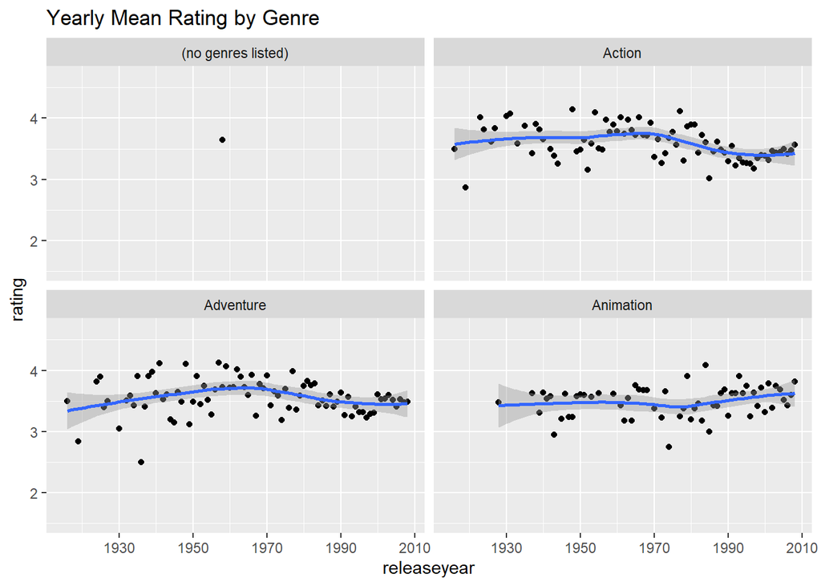

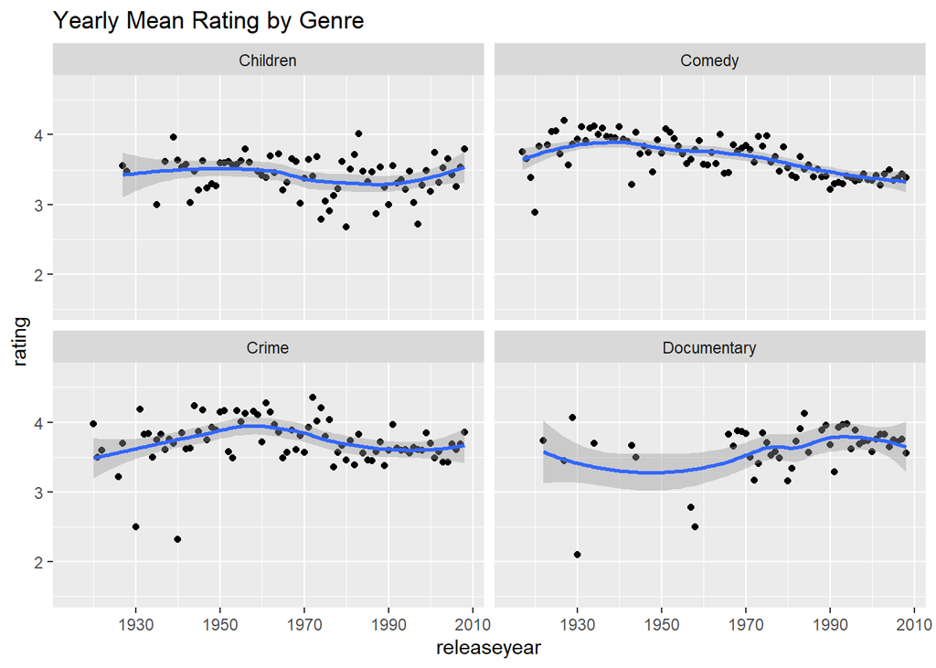

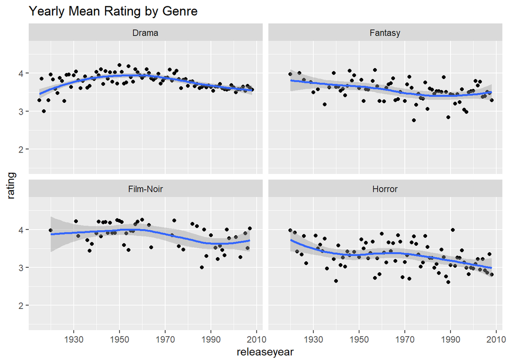

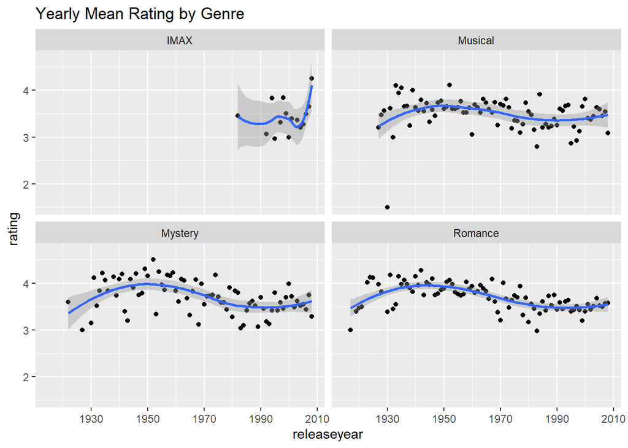

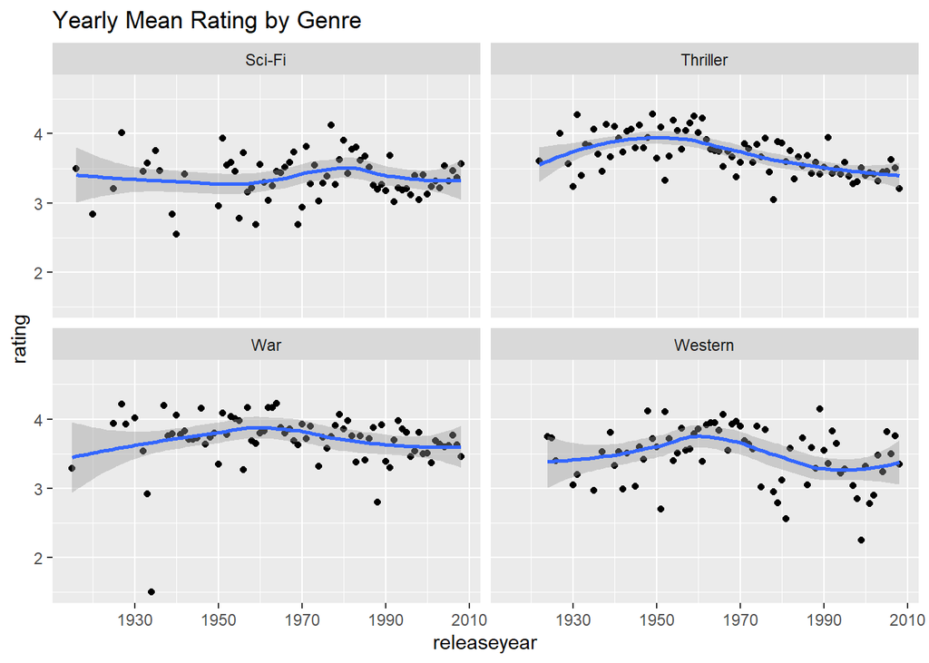

When seperated by genre, it appears that many genres follow the general pattern, but others, such as Documentary and Horror, displaying a different pattern.

### Effect of Delayed Rating

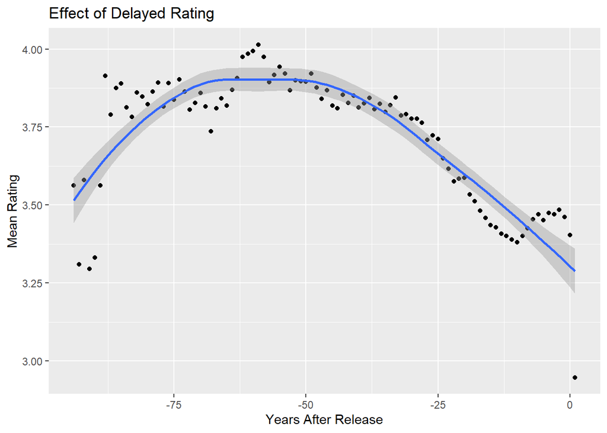

The delay between the movies release and its rating also appears to have an effect.

### Delayed Rating’s Effect by Genre

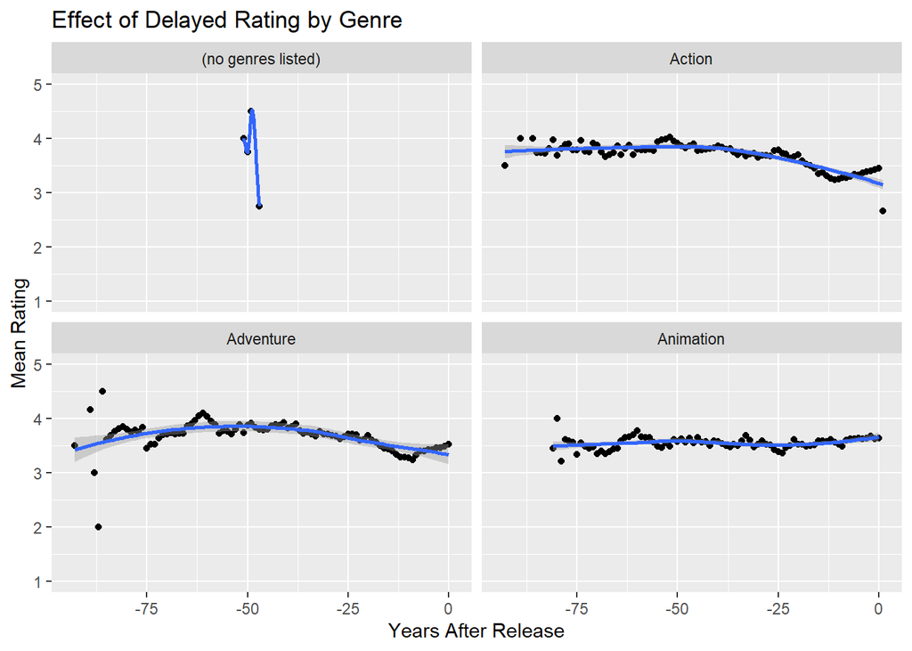

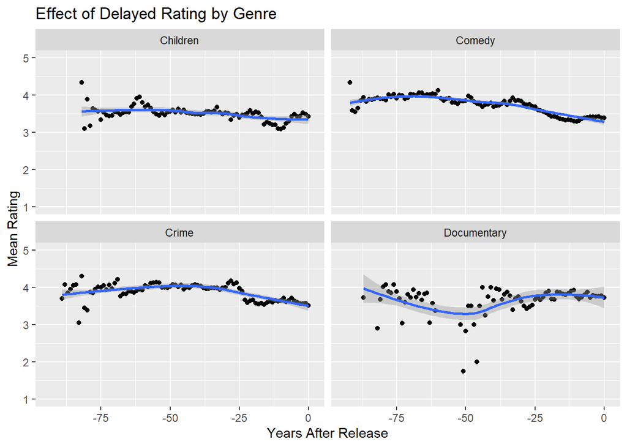

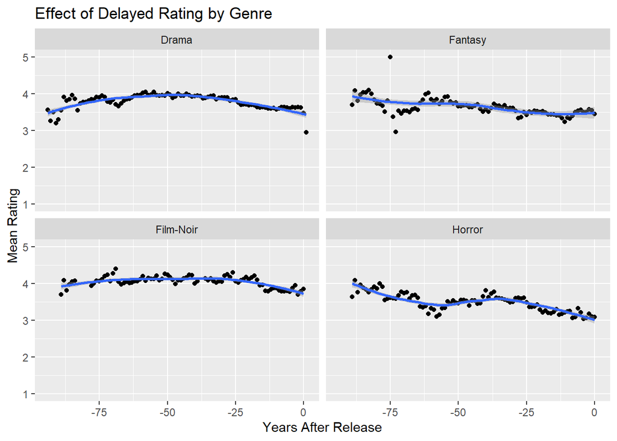

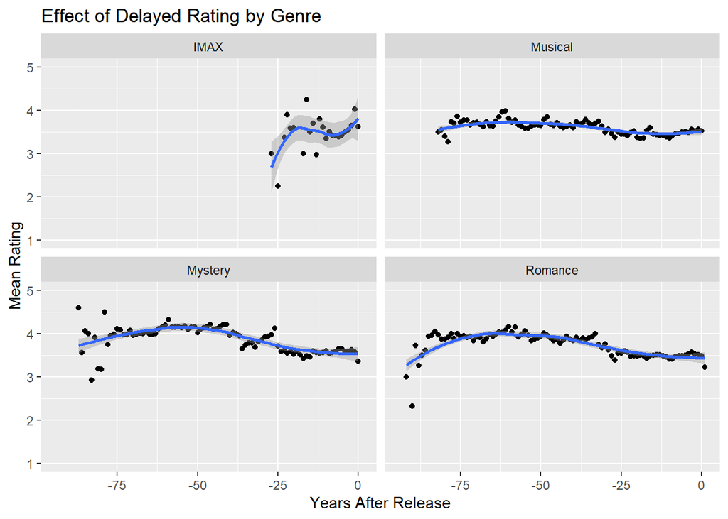

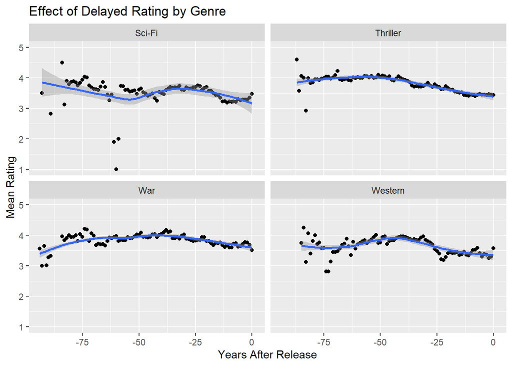

Similarly to above, we can see some genres follow the general trend and some do not.

## Conclusions

# Recommendation Systems

## Defining RMSE

Before we start to create and test our models, we first need to define how we will judge them. For this, as in the competition, we will use the Root Mean Squared Error.

## Creating Train and Test Sets

In order to gauge the accuracy of our recommendation systems, we will partition 10% of the EdX set to use as a test set. This will allow us to keep the Validation set we already created for our final test, and help insure the reliability of our systems.

## Mean and Biases Based Models

### Simple Mean Rating

This is the simplest recommendation system. It simply uses the mean rating, and is based on the assumption that all remaining differences can be explained by random variation.

RMSE Results

| method | RMSE |
| --- | --- |
| Just the average | 1.060054 |

This RMSE equates to our typical error being just over 1 star. This is not particularly good, and falls short of our target RMSE.

### Adding Movie Bias

As common experience tells us, some movies are generally rated higher than other. In this model, we will incorporate that, and base the model on the assumption that the differences in ratings can be explained by the mean plus the individual movie bias, which we will call bi, and assume that all other variance is random.

RMSE Results

| method | RMSE |
| --- | --- |
| Just the average | 1.0600537 |
| With Movie Bias | 0.9429615 |

This approach has reduced our RMSE by ~ .1 of a star. Although we are moving in the right direction, more explanation of the remaining variance is needed.

### Adding User Bias

RMSE Results

| method | RMSE |
| --- | --- |
| Just the average | 1.0600537 |
| With Movie Bias | 0.9429615 |
| With Movie Bias and User Bias | 0.8646844 |

We have gotten a reduction of ~.08 on our previous RMSE score. However, it is still above our target RMSE.

### Adding Release Year Bias

As we saw earlier, the year the movie was released appears to have an effect on the rating. This variable can be added to our model, which we will refer to as br.

RMSE Results

| method | RMSE |
| --- | --- |
| Just the average | 1.0600537 |
| With Movie Bias | 0.9429615 |
| With Movie Bias and User Bias | 0.8646844 |
| With Movie Bias and User Bias and Release Year Bias | 0.8643302 |

Although we still see a reduction in our RMSE, it only represents a tiny fraction of a star.

### Adding Genre Bias

Some genres are rated higher than other, we have seen in our analysis that Film-Noir, Documentary, and War movies are the highest rated. This can be added to our model, using a variable we will call bg.

RMSE Results

| method | RMSE |
| --- | --- |
| Just the average | 1.0600537 |
| With Movie Bias | 0.9429615 |
| With Movie Bias and User Bias | 0.8646844 |
| With Movie Bias and User Bias and Release Year Bias | 0.8643302 |
| With Movie Bias, User Bias, Release Year Bias, and Genre Bias | 0.8623595 |

This results in another small decrease in our RMSE.

### Replacing Release Year and Genre Bias for Release Year by Genre Bias

We have already seen how the Release Year Bias has a different effect depending on the genre. Lets try to model that effect. We will call this variable brg.

RMSE Results

| method | RMSE |
| --- | --- |
| Just the average | 1.0600537 |
| With Movie Bias | 0.9429615 |
| With Movie Bias and User Bias | 0.8646844 |
| With Movie Bias and User Bias and Release Year Bias | 0.8643302 |
| With Movie Bias, User Bias, Release Year Bias, and Genre Bias | 0.8623595 |
| With Movie Bias, User Bias, and Release Year by Genre Bias | 0.8622556 |

This approach results in almost no difference.

### Replacing Release Year by Genre Bias for Delayed Rating Bias

We already know that the amount of time between a movies release and its rating has an effect on its rating. We can name this brr.

RMSE Results

| method | RMSE |
| --- | --- |
| Just the average | 1.0600537 |
| With Movie Bias | 0.9429615 |
| With Movie Bias and User Bias | 0.8646844 |
| With Movie Bias and User Bias and Release Year Bias | 0.8643302 |
| With Movie Bias, User Bias, Release Year Bias, and Genre Bias | 0.8623595 |
| With Movie Bias, User Bias, and Release Year by Genre Bias | 0.8622556 |
| With Movie Bias, User Bias, and Release/Review Bias | 0.8622619 |

### Adding Genre Bias

Lets add the genre bias back into the model. We should recalculate this first. We will refer to this as brrg.

RMSE Results

| method | RMSE |
| --- | --- |
| Just the average | 1.0600537 |
| With Movie Bias | 0.9429615 |
| With Movie Bias and User Bias | 0.8646844 |
| With Movie Bias and User Bias and Release Year Bias | 0.8643302 |
| With Movie Bias, User Bias, Release Year Bias, and Genre Bias | 0.8623595 |
| With Movie Bias, User Bias, and Release Year by Genre Bias | 0.8622556 |
| With Movie Bias, User Bias, and Release/Review Bias | 0.8622619 |
| With Movie Bias, User Bias, Release/Review Bias, and genre | 0.8621862 |

The reduction is negligible.

### Replacing Delayed Review Bias for Delayed Review by Genre Bias.

We’ve shown that the effect of a Delayed Review can be very different depending on the genre. For this we will use brrg2.

RMSE Results

| method | RMSE |
| --- | --- |
| Just the average | 1.0600537 |
| With Movie Bias | 0.9429615 |
| With Movie Bias and User Bias | 0.8646844 |
| With Movie Bias and User Bias and Release Year Bias | 0.8643302 |
| With Movie Bias, User Bias, Release Year Bias, and Genre Bias | 0.8623595 |
| With Movie Bias, User Bias, and Release Year by Genre Bias | 0.8622556 |
| With Movie Bias, User Bias, and Release/Review Bias | 0.8622619 |
| With Movie Bias, User Bias, Release/Review Bias, and genre | 0.8621862 |
| With Movie Bias, User Bias, and Release/Review Bias by Genre | NA |

This approach results in NAs being created. The following code can be used to identify the cause.

Entries with NA’s

| userId | movieId | rating | timestamp | title | genres | releaseyear | date | release_review | b_i | b_u | b_r_r_g2 | pred |
| --- | --- | --- | --- | --- | --- | --- | --- | --- | --- | --- | --- | --- |
| 6477 | 3136 | 3.5 | 1136352253 | James Dean Story, The (1957) | Documentary | 1957 | 2006 | -49 | -0.8874568 | 0.0218258 | NA | NA |
| 16929 | 3136 | 3.0 | 1221163759 | James Dean Story, The (1957) | Documentary | 1957 | 2009 | -52 | -0.8874568 | -0.5584057 | NA | NA |
| 30013 | 3136 | 3.5 | 1099285247 | James Dean Story, The (1957) | Documentary | 1957 | 2005 | -48 | -0.8874568 | 0.1443231 | NA | NA |

We can see that the issue is not having any training data for a documentary with a delayed rating of -48, -49, and -52 years. There are possible solutions for this issue, However that is beyond the scope of this project.

We have seen a diminishing return for our efforts with this strategy. Instead of continuing to try and explain the remaining variance by adding more variables, let’s try to a new approach.

## Regularization

Earlier in analysis, we noted that there is a substantial variance in how often users rated individual movies. We also say that can skew the mean ratings, with some movies having a perfect 5 star rating from a single rating. In order to address this, we will use a Penalised Least Squares approach.

### Penalised Least Squares

The first step is to select a value for lambda, in this case the one which produces the lowest RMSE. To help us select the best choice, we can evaluate a sequence of them.

#### Regularized Movies

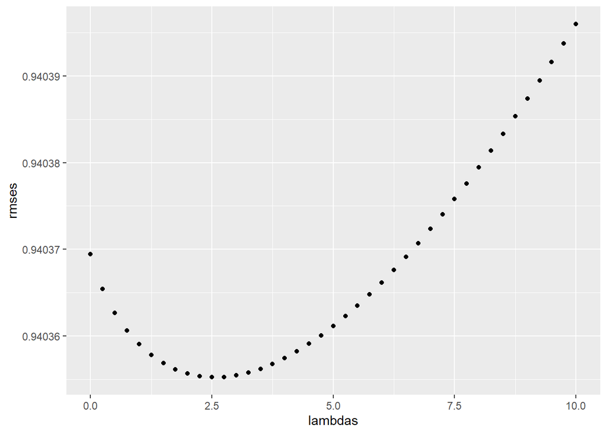

Lambda with Lowest RMSE

| x |
| --- |
| 2.5 |

We can now use this value for our model.

RMSE Results

| method | RMSE |
| --- | --- |
| Just the average | 1.0600537 |
| With Movie Bias | 0.9429615 |
| With Movie Bias and User Bias | 0.8646844 |
| With Movie Bias and User Bias and Release Year Bias | 0.8643302 |
| With Movie Bias, User Bias, Release Year Bias, and Genre Bias | 0.8623595 |
| With Movie Bias, User Bias, and Release Year by Genre Bias | 0.8622556 |
| With Movie Bias, User Bias, and Release/Review Bias | 0.8622619 |
| With Movie Bias, User Bias, Release/Review Bias, and genre | 0.8621862 |
| With Movie Bias, User Bias, and Release/Review Bias by Genre | NA |
| With Regularised Movie | 0.9403552 |

Regularizing movies has resulted a modest reduction when compared to the non-regularized movie bias alone. However, we still have not reached our target RMSE.

Lets try to add some biases.

#### Regularized Movie and User Bias

We can start with adding User Bias, in much the same way we did before.

RMSE Results

| method | RMSE |
| --- | --- |
| Just the average | 1.0600537 |
| With Movie Bias | 0.9429615 |
| With Movie Bias and User Bias | 0.8646844 |
| With Movie Bias and User Bias and Release Year Bias | 0.8643302 |
| With Movie Bias, User Bias, Release Year Bias, and Genre Bias | 0.8623595 |
| With Movie Bias, User Bias, and Release Year by Genre Bias | 0.8622556 |
| With Movie Bias, User Bias, and Release/Review Bias | 0.8622619 |
| With Movie Bias, User Bias, Release/Review Bias, and genre | 0.8621862 |
| With Movie Bias, User Bias, and Release/Review Bias by Genre | NA |
| With Regularised Movie | 0.9403552 |
| With Regularised Movie and User Bias | 0.8629317 |

Adding the User bias has brought the RMSE down to 0.863

Let’s add another bias.

#### Regularized Movie and User Bias, with Release Year by Genre Bias

Let’s try to add the Release Year by Genre Bias.

RMSE Results

| method | RMSE |
| --- | --- |
| Just the average | 1.0600537 |
| With Movie Bias | 0.9429615 |
| With Movie Bias and User Bias | 0.8646844 |
| With Movie Bias and User Bias and Release Year Bias | 0.8643302 |
| With Movie Bias, User Bias, Release Year Bias, and Genre Bias | 0.8623595 |
| With Movie Bias, User Bias, and Release Year by Genre Bias | 0.8622556 |
| With Movie Bias, User Bias, and Release/Review Bias | 0.8622619 |
| With Movie Bias, User Bias, Release/Review Bias, and genre | 0.8621862 |
| With Movie Bias, User Bias, and Release/Review Bias by Genre | NA |
| With Regularised Movie | 0.9403552 |
| With Regularised Movie and User Bias | 0.8629317 |
| With Regularised Movie. User Bias, and Release Year by Genre Bias | 0.8623673 |

We have now gotten the RMSE down to 0.862.

Although we have gotten the RMSE down, we still haven’t been able to reach our target.

## Matrix Factorization

### What is recosystem

The recosystem package is a r wrapper for the open source, LIBMF library for recommendation systems. Developed by Yu-Chin Juan, Wei-Sheng Chin, et al. (3), this package holds many advantages, not only over our previous approaches, but also when compared other systems that utilize a matrix factorization method. Recosystem, as well as the LIBMF library it is based on, allows users to take advantage of multi-core processing, improving performance times, as well better memory management stratigies.

### Setings

The recosystem allows for a wide range of customization through it’s peramiters and options. This includes the nthread parameter, which defines the number of threads for parallel computing. For this project, it has not been changed from the default value of 1. This is due to when nthread is set to a value greater than 1, the training result can not be guaranteed to be reproducable, even if random seed is set.(4)

### Recosystem Model

The recosystem requires us to first specify our train train and test set, before we can use it’s inbuilt tuning feature to optimize it’s options.

```
## iter      tr_rmse          obj
##    0       0.8927   2.3616e+07
##    1       0.8057   2.0209e+07
##    2       0.7633   1.8697e+07
##    3       0.7390   1.7949e+07
##    4       0.7231   1.7479e+07
##    5       0.7118   1.7179e+07
##    6       0.7036   1.6966e+07
##    7       0.6973   1.6800e+07
##    8       0.6924   1.6683e+07
##    9       0.6883   1.6598e+07
##   10       0.6851   1.6515e+07
##   11       0.6823   1.6457e+07
##   12       0.6799   1.6411e+07
##   13       0.6779   1.6368e+07
##   14       0.6760   1.6331e+07
##   15       0.6744   1.6302e+07
##   16       0.6729   1.6265e+07
##   17       0.6717   1.6247e+07
##   18       0.6705   1.6232e+07
##   19       0.6694   1.6212e+07
```

RMSE Results

| method | RMSE |
| --- | --- |
| Just the average | 1.0600537 |
| With Movie Bias | 0.9429615 |
| With Movie Bias and User Bias | 0.8646844 |
| With Movie Bias and User Bias and Release Year Bias | 0.8643302 |
| With Movie Bias, User Bias, Release Year Bias, and Genre Bias | 0.8623595 |
| With Movie Bias, User Bias, and Release Year by Genre Bias | 0.8622556 |
| With Movie Bias, User Bias, and Release/Review Bias | 0.8622619 |
| With Movie Bias, User Bias, Release/Review Bias, and genre | 0.8621862 |
| With Movie Bias, User Bias, and Release/Review Bias by Genre | NA |
| With Regularised Movie | 0.9403552 |
| With Regularised Movie and User Bias | 0.8629317 |
| With Regularised Movie. User Bias, and Release Year by Genre Bias | 0.8623673 |
| Recosystem | 0.7896290 |

# Final Validation

By using the Recosystem, we have gotten the lowest RMSE, one well below our target. However, this has only been tested on data from our Edx set. We must now test it on our Validation set, in order to get a more reliable RMSE.

```
## iter      tr_rmse          obj
##    0       0.9568   1.0889e+07
##    1       0.8606   9.2349e+06
##    2       0.8150   8.5443e+06
##    3       0.7881   8.1842e+06
##    4       0.7698   7.9687e+06
##    5       0.7560   7.8076e+06
##    6       0.7454   7.6957e+06
##    7       0.7368   7.6063e+06
##    8       0.7298   7.5403e+06
##    9       0.7241   7.4804e+06
##   10       0.7193   7.4371e+06
##   11       0.7152   7.3990e+06
##   12       0.7117   7.3648e+06
##   13       0.7089   7.3405e+06
##   14       0.7062   7.3169e+06
##   15       0.7040   7.2993e+06
##   16       0.7019   7.2794e+06
##   17       0.7001   7.2644e+06
##   18       0.6985   7.2516e+06
##   19       0.6970   7.2381e+06
```

RMSE Results

| method | RMSE |
| --- | --- |
| Just the average | 1.0600537 |
| With Movie Bias | 0.9429615 |
| With Movie Bias and User Bias | 0.8646844 |
| With Movie Bias and User Bias and Release Year Bias | 0.8643302 |
| With Movie Bias, User Bias, Release Year Bias, and Genre Bias | 0.8623595 |
| With Movie Bias, User Bias, and Release Year by Genre Bias | 0.8622556 |
| With Movie Bias, User Bias, and Release/Review Bias | 0.8622619 |
| With Movie Bias, User Bias, Release/Review Bias, and genre | 0.8621862 |
| With Movie Bias, User Bias, and Release/Review Bias by Genre | NA |
| With Regularised Movie | 0.9403552 |
| With Regularised Movie and User Bias | 0.8629317 |
| With Regularised Movie. User Bias, and Release Year by Genre Bias | 0.8623673 |
| Recosystem | 0.7896290 |
| Final Validation: Recosystem | 0.7845712 |

Our final RMSE score is 0.7845, far below our stated target of 0.8567.

# Conclusions

# References and Acknowledgements

## References

1. Wikipedia, Netflix Prize: https://en.wikipedia.org/wiki/Netflix_Prize
2. Grouplens.org, MovieLens 10M Dataset : https://grouplens.org/datasets/movielens/10m/
3. Yixuan Qiu, recosystem: Recommender System Using Parallel Matrix Factorization, https://cran.r-project.org/web/packages/recosystem/vignettes/introduction.html
4. Yixuan’s Blog - R, https://www.r-bloggers.com/2016/07/recosystem-recommender-system-using-parallel-matrix-factorization/

## Acknowledgements

Numerous parts of the above code, including, but not limited to, the code for importing and creating the data sets, were either supplied as a part of this capstone project, or were directly taken from related HarvardX course materials: Rafael A. Irizarry, Introduction to Data Science:Data Analysis and Prediction Algorithms with R, https://rafalab.github.io/dsbook/